# Forest Phenology Data Analysis Report

## **Step 3:** **Budburst Date Estimation for 2019**

- The same method was consistently applied to the 2019 data as well.
- After cleaning outliers (>50°C) and applying the GDD threshold, cumulative GDD was computed.
- The first day in 2019 when the cumulative GDD surpassed the threshold of 204.76 was identified:

Estimated Budburst Date in 2019: March 31 (DOY = 90)

```r
# ----------- GDD Estimation for 2019 ------------

# Extract 2019 temperature row
temp_2019 <- as.numeric(budburst_data[2, ])

# Remove unrealistic values > 50°C
temp_2019[temp_2019 > 50] <- NA

# Replace NA with 0 to continue safely
temp_2019[is.na(temp_2019)] <- 0

# Compute daily heat and cumulative GDD for 2019
daily_heat_2019 <- pmax(temp_2019 - T_threshold, 0)
cumulative_GDD_2019 <- cumsum(daily_heat_2019)

# Identify first DOY in 2019 when cumulative GDD ≥ GDD_2018
budburst_day_2019 <- which(cumulative_GDD_2019 >= GDD_2018)[1]

# Convert DOY to calendar date
budburst_date_2019 <- as.Date(budburst_day_2019 - 1, origin = "2019-01-01")
print(budburst_date_2019)
```

```
## [1] "2019-03-31"
```

## **Interpretation**

- The tree in 2019 reached the required heat accumulation approximately **16 days earlier** than in 2018.
- The advancement of GDD accumulation in 2019 indicates a warmer late winter and early spring, which likely contributed to accelerated phenological development.
- This interannual variation is important for understanding climate sensitivity in temperate forest ecosystems.

## **Step 4: Plot GDD for Both Years**

The research team plotted a cumulative Growing Degree Day (GDD) graph for both years to illustrate the differences in heat accumulation patterns over time.

```r
# ----------- GDD Line Plot (2018 vs 2019) ------------

# Determine number of days in the dataset
num_days <- ncol(budburst_data)
```

```r
# Recompute GDD series for both years (with NA cleaning)
temp_2018 <- as.numeric(budburst_data[1, 1:num_days])
temp_2018[temp_2018 > 50] <- NA
temp_2018[is.na(temp_2018)] <- 0
daily_heat_2018 <- pmax(temp_2018 - T_threshold, 0)
cumulative_GDD_2018 <- cumsum(daily_heat_2018)
```

```r
# Create tidy tibble for plotting
gdd_data <- tibble(
  DayOfYear = 1:num_days,
  GDD_2018 = cumulative_GDD_2018,
  GDD_2019 = cumulative_GDD_2019[1:num_days]
)
```

```r
# Pivot data for ggplot
gdd_long <- gdd_data %>%
  pivot_longer(cols = c(GDD_2018, GDD_2019),
               names_to = "Year",
               values_to = "GDD")
```

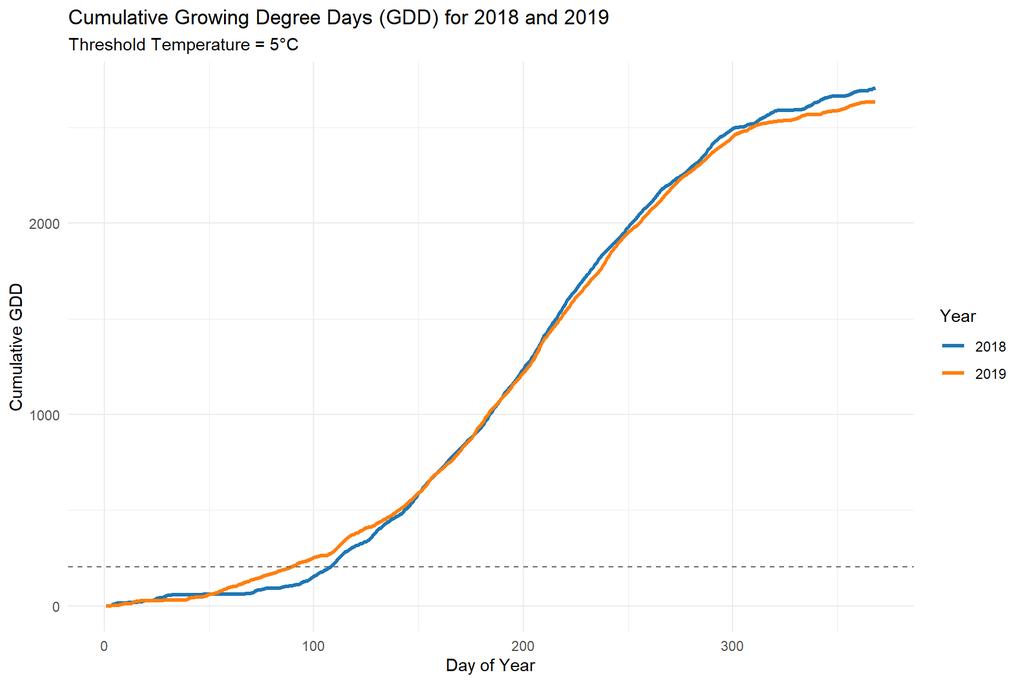

```r
# Plot cumulative GDD for both years

cumulative_GDD_plot <- ggplot(gdd_long, aes(x = DayOfYear, y = GDD, color = Year)) +
  geom_line(size = 1.2) +
  geom_hline(yintercept = GDD_2018, linetype = "dashed", color = "gray40") +
  labs(
    title = "Cumulative Growing Degree Days (GDD) for 2018 and 2019",
    subtitle = "Threshold Temperature = 5°C",
    x = "Day of Year",
    y = "Cumulative GDD",
    color = "Year"
  ) +
  scale_color_manual(values = c("GDD_2018" = "#1f77b4", "GDD_2019" = "#ff7f0e"),
                     labels = c("2018", "2019")) +
  theme_minimal()

print(cumulative_GDD_plot)
```

## **Conclusion**

This GDD-based approach enables effective prediction of phenological events such as budburst. The results illustrate how relatively small shifts in daily temperatures can significantly alter plant development timelines. Such findings are valuable for climate impact assessments, forest management, and ecological forecasting.